# Programação – expressions

## Expressões

### Diogo Silva

#### CAP / ENGEL

dasilva@academiafa.edu.pt

### O que são?

Expressões devolvem sempre um valor concreto com um determinado tipo.

```c
    int raio = 2;
    float area = 3.14 * raio * raio;
```

### Operações aritméticas

```c
1+2    // soma
3.14-2 // subtração
1*2.3  // multiplicação
5/2    // divisão, devolve 2 -> porquê?
5%2    // resto da divisão

int v = 2;
-v     // torna valor negativo, operação unária
```

–

Operação unária? Operação que recebe apenas 1 operando.

Por outro lado, as outras operações são binárias (2 operandos).

–

⚠️ Cuidado com a divisão! ⚠️

O operador para a divisão, quando recebe 2 operandos inteiros, devolve sempre um valor inteiro (ignorando, sem arredondamento, a parte decimal)

```c
5/2 // devolve 2
```

Quando misturamos um inteiro com um real, o inteiro é automaticamente convertido e o resultado será o valor preciso

```c
5.0/2 // devolve 2.5
```

–

O resto da divisão `%` requer 2 operandos inteiros.

Usar 0 como o segundo operando da divisão `/` ou resto da divisão `%`, i.e. divisão por 0, gera comportamento não definido.

### Precedência e associatividade

`1+2*-2`

É o tipo de expressão que não devem escrever. Devem usar () para melhorar legibilidade.

Mas se vissem esta expressão, qual seria o resultado?

–

As operações no C têm uma precedência.

| Precedência | Operadores |
| --- | --- |
| Alta | + - unários (e.g. -2) |
| `---` | * / % |
| Baixa | + - |

`1 + 2 * -2 == 1 + (2 * (-2))`

–

`i + j * k == i + (j * k)`

`-i * -j == (-i) * (-j)`

–

E quando uma expressão tem 2 operações com a mesma precedência?

`i - j + k`

`i / j * k`

–

Tem-se em conta a associatividade.

`i - j + k == (i - j) + k`

`i / j * k == (i / j) * k`

`+ - * / %` têm associtividade à esquerda, o que quer dizer que agrupam o que está antes do operador.

Os operadores unários têm associatividade à direita.

`- -2 == - (-2)`

### Operadores de atribuição

Já conhecemos o operador de atribuição simples `=`.

É o que designamos por uma operação com **efeitos secundários**, porque altera o estado dos operandos.

–

`a = 2` altera o estado da variável `a` porque o seu valor é agora 2.

Adicionalmente, `a = 2` é uma expressão válida que devolve o valor que foi atribuido à variável

```c
int a=10;
printf("a=%d\n", a=2); // escreve 2 na consola e altera o valor de a
```

–

Todas as operações de atribuição exigem que o operando da esquerda seja uma variável.

–

Existem outros que se combinam com operações aritméticas.

[output not shown]

–

`v*=3` não é equivalente a `v = v * 3`, embora na maior parte das utilizações o resultado seja o mesmo.

Porquê? Observem a expressão `v*=3+10`

Não é equivalente a `v = v * 3 + 10`. Esta expressão, deviso às regras de precedência a associatividade iria dar um resultado diferente.

```c
int a=3;
printf("a=%d\n", (a = a * 3 + 10)); // a=19
a=3;
printf("a=%d\n", a*=3+10); // a=39
```

–

Não confundir `+=` com `=+`.

A primeira operação acumula o valor à direita.

–

Posto isto, usem **sempre** ( ) para deixar claro qual é a ordem das operações.

### Incremento e decremento

Existe uma instrução que é frequentemente usada no C (irão perceber porquê quando abordarmos ciclos):

```c
i = i + 1;
i += 1;
```

–

Existe outra forma de escrever esta instrução, com o operador de incremento `++`

```
i = i + 1;
i += 1;
i++;
```

–

Este operador pode ser usado tanto antes de uma variável (pré-incremento) como depois (pós-incremneto).

Qual será a diferença?

```c
int i=10;
printf("%d\n", ++i); // ?
printf("%d\n", i);   // ?
i=10;
printf("%d\n", i++); // ?
printf("%d\n", i);   // ?
```

–

```c
int i=10;
printf("%d\n", ++i); // 11
printf("%d\n", i);   // 11
i=10;
printf("%d\n", i++); // 10
printf("%d\n", i);   // 11
```

–

Além do incremento `++`, também temos disponível o decremento `--`, que funciona da mesma forma, mas subtrai em uma unidade.

### Avaliação de expressões

Resumo das operações que já vimos:

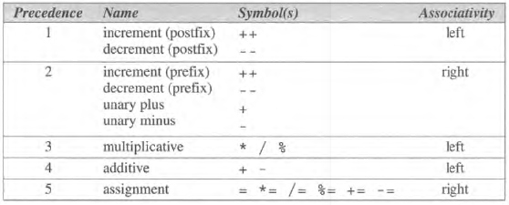

postfix == pós-incremento

prefix == pré-incremento

–

Com este conhecimento conseguimos avaliar expressões complicadas.

`a= b += c++ - d + --e / -f`

1. Encontrar o operador com maior precedência.
2. Colocar ( ) à volta do operador e operandos.
   1. Aplicar regras de precedência e associatividade.
3. Repetir.

–

`a= b += c++ - d + --e / -f`

c++ e depois –e (precedência)

`a= b += (c++) - d + (--e) / -f`

operador unário -f (precedência)

`a= b += (c++) - d + (--e) / (-f)`

divisão (precedência)

`a= b += (c++) - d + ((--e) / (-f))`

–

`a= b += (c++) - d + ((--e) / (-f))`

- e + com a mesma precedência e com operando em comum d (precedência)

agrupam da esquerda para a direita, logo - primeiro (associatividade)

`a= b += ((c++) - d) + ((--e) / (-f))`

e depois o + (precedência)

`a= b += (((c++) - d) + ((--e) / (-f)))`

= e += com mesma precedência (precedência)

agrupam da direita para a esquerda, logo += primeiro (associatividade)

`a= (b += (((c++) - d) + ((--e) / (-f))))`

sobra apenas o = (precedência)

`(a= (b += (((c++) - d) + ((--e) / (-f)))))`